# Milestone Report

Jani Savolainen

21 January 2019

## Summary

This the milestone report for the Coursera Data Scienence Specialization course. The goal was to build basic n-gram model to see the frequencies of the different word combinations. With that data it is possible to build an algorhitm predicting the next word the user is typing with the previous words.

## Loading the data

```r
setwd("~/Data_Science_Specialization/capstone_project")
library(stringi)
```

```r
dataUrl <- "https://d396qusza40orc.cloudfront.net/dsscapstone/dataset/Coursera-SwiftKey.zip"
fileName <- "data/Coursera-SwiftKey.zip"
sourceFolder <- "~/Data_Science_Specialization/capstone_project/data/final"

## load the zip if it does not exist
if (!file.exists(fileName)) {
        download.file(dataUrl, fileName, mode = "wb")
        unzip(fileName)
}

list.files("final/en_US")
```

```
## [1] "en_US.blogs.txt"   "en_US.news.txt"    "en_US.twitter.txt"
```

```r
## read the blogs and twitter files with readLines function
blogs <- readLines("./final/en_US/en_US.blogs.txt", encoding = "UTF-8")
twitter <- readLines("./final/en_US/en_US.twitter.txt", warn = FALSE, encoding="UTF-8")
news <- readLines("./final/en_US/en_US.news.txt", warn = FALSE, encoding="UTF-8")
```

## Basic summaries of the files

Generate a summery of the three files including count of lines, words, characters, longest row and file size.

```r
wordsTwitter <- stri_stats_latex(twitter)[4]
charTwitter <- sum(nchar(twitter))
longrowTwitter <- max(nchar(twitter))
sizeTwitter <- (file.info("./final/en_US/en_US.twitter.txt"))$size / 1024 ^ 2

wordsBlogs <- stri_stats_latex(blogs)[4]
charBlogs <- sum(nchar(blogs))
longrowBlogs <- max(nchar(blogs))
sizeBlog <- (file.info("./final/en_US/en_US.blogs.txt"))$size / 1024 ^ 2

wordsNews <-stri_stats_latex(news)[4]
charNews<-sum(nchar(news))
longrowNews <- max(nchar(news))
sizeNews <- (file.info("./final/en_US/en_US.news.txt"))$size / 1024 ^ 2

data.frame("source" = c("twitter", "blogs", "news"),
           "lines" = c(length(twitter),length(blogs), length(news)),
           "words" = c(wordsTwitter, wordsBlogs,wordsNews),
           "characters"=c(charTwitter,charBlogs, charNews),
           "longest line"=c(longrowTwitter,longrowBlogs,longrowNews),
           "file size"=c(sizeTwitter, sizeBlog, sizeNews))
```

```
##    source   lines    words characters longest.line file.size
## 1 twitter 2360148 30451128  162096031          140  159.3641
## 2   blogs  899288 37570839  206824505        40833  200.4242
## 3    news   77259  2651432   15639408         5760  196.2775
```

## Create a sample and clean the data

Let’s create a sample with 5 percent of each data set. Let’s get rid of the punctuation.

```r
set.seed(112) # set seed to be able to reproduce the sampling
library(caret)
library(tm) # text mining library
## let's do a sample data set which includes 5 percent of each data set
sampleTwitter <- sample(twitter, length(twitter) * 0.05)
sampleBlogs <- sample(blogs, length(blogs) * 0.05)
sampleNews <- sample(news, length(news) * 0.05)

sampleData <- c(sampleTwitter, sampleBlogs, sampleNews)
sampleData <- removePunctuation(sampleData) # remove punctuation
summary(sampleData)
```

```
##    Length     Class      Mode
##    166833 character character
```

## Create corpus and ngrams

Let’s create a corpus and store the ngrams as a Natural Language Prpcessing friendly document-feature matrixes with quanteda package.

```r
## as I did not get Rweka package working, I had to develop something else. I found quanteda which can do both corpus and ngrams.
library(quanteda)
```

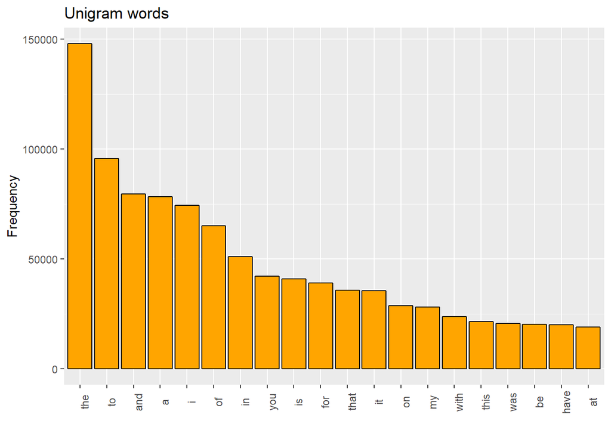

```r
corpus <- corpus(sampleData)

unigrams<-dfm(corpus,
              ngrams = 1)
headUnigrams <- data.frame(topfeatures(unigrams, 20)); names(headUnigrams) <- c("frequency"); # make a df
headUnigrams$words <- rownames(headUnigrams); # make rown names as a column
headUnigrams$words <- factor(headUnigrams$words, levels = headUnigrams$words[order(-headUnigrams$frequency)]) # sort

## do the same for bi, tri and 4-grams
bigrams <- dfm(corpus,
             ngrams = 2,
             concatenator=" ")
headBigrams <- data.frame(topfeatures(bigrams, 20)); names(headBigrams) <- c("frequency"); # make a df
headBigrams$words <- rownames(headBigrams); # make rown names as a column
headBigrams$words <- factor(headBigrams$words, levels = headBigrams$words[order(-headBigrams$frequency)]) # sort

trigrams <- dfm(corpus,
              ngrams = 3,
              concatenator=" ")
headTrigrams <- data.frame(topfeatures(trigrams, 20)); names(headTrigrams) <- c("frequency"); # make a df
headTrigrams$words <- rownames(headTrigrams); # make rown names as a column
headTrigrams$words <- factor(headTrigrams$words, levels = headTrigrams$words[order(-headTrigrams$frequency)]) # sort

fourgram <- dfm(corpus,
                ngrams = 4,
                concatenator=" ")
headFourgram <- data.frame(topfeatures(fourgram, 20)); names(headFourgram) <- c("frequency"); # make a df
headFourgram$words <- rownames(headFourgram); # make rown names as a column
headFourgram$words <- factor(headFourgram$words, levels = headFourgram$words[order(-headFourgram$frequency)]) # sort

## crate graphs

unigg <- ggplot(headUnigrams, aes(headUnigrams$words, headUnigrams$frequency)) # make graph
unigg + geom_bar(stat='identity', col="black", fill="orange")+labs(title="Unigram words", x="",y="Frequency") +
        theme(axis.text.x = element_text(angle = 90))
```

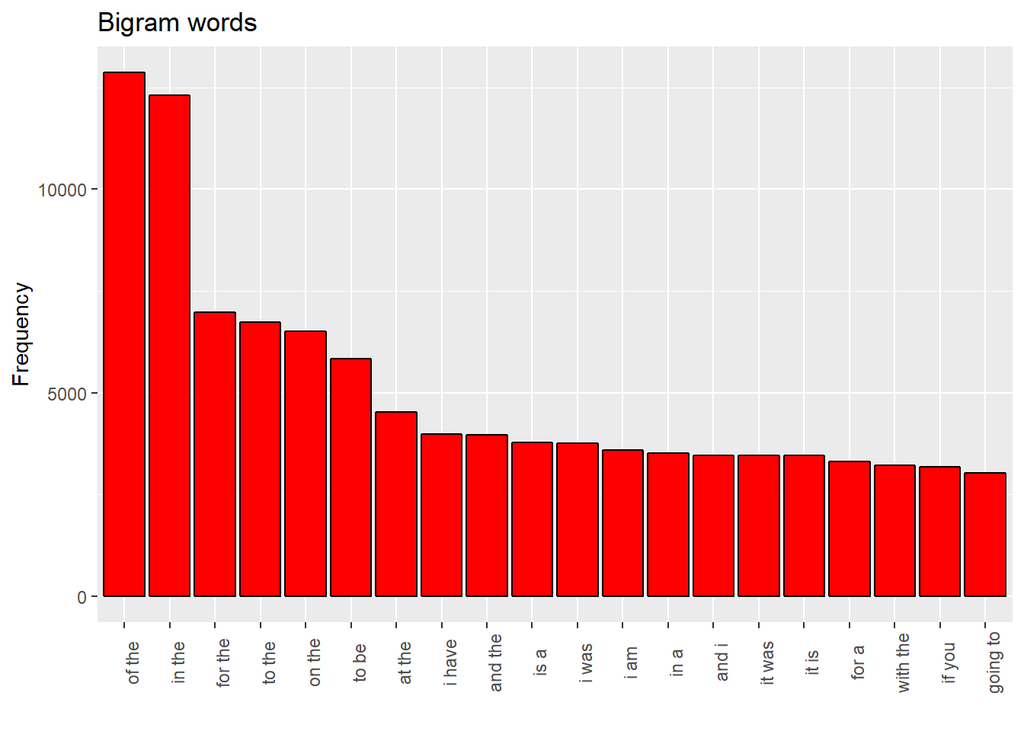

```r
bigg <- ggplot(headBigrams, aes(headBigrams$words, headBigrams$frequency)) # make graph
bigg + geom_bar(stat='identity', col="black", fill="red")+labs(title="Bigram words", x="",y="Frequency") +
        theme(axis.text.x = element_text(angle = 90))
```

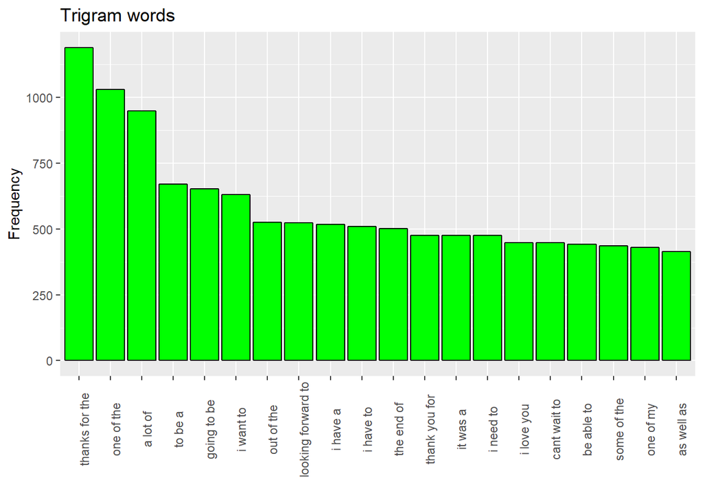

```r
trigg <- ggplot(headTrigrams, aes(headTrigrams$words, headTrigrams$frequency)) # make graph
trigg + geom_bar(stat='identity', col="black", fill="green")+labs(title="Trigram words", x="",y="Frequency") +
theme(axis.text.x = element_text(angle = 90))
```

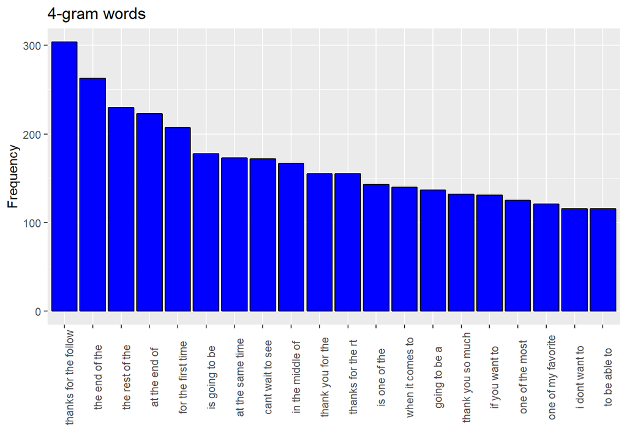

```r
fourgg <- ggplot(headFourgram, aes(headFourgram$words, headFourgram$frequency)) # make graph
fourgg + geom_bar(stat='identity', col="black", fill="blue")+labs(title="4-gram words", x="",y="Frequency") +
        theme(axis.text.x = element_text(angle = 90))
```

## Findings

As we can see from the charts, the is the most popular word in the sample data. The most popular bigrams are “of the” and “in the”. Most popular trigram “thanks for the” and fourgram “thanks for the follow”. Context really matters as the most popular fourgram is quite irrelevant outside the Twitter and the trigram seems to refer that too.

Building the ngrams with the chosen tecnology seems to be slow so for live predictions this would not be good.

## Next step

Next step is to build a bigger corpus and the a predictive algorhitm based on that. On solution could be that the algorhitm would first see the trigrams for the best prediction and if there is no match, then unigram and finally to unigram.

The final capstone project is to build a Shiny app and deploy the predictive algorhitm with it.